# Time Series

Fernando

2022-11-17

# Time Series

Uma série temporal é, basicamente, uma sequência de observações tomada ao longo de um período de tempo. Diversos conjuntos de dados se apresentam como uma série temporal, como por exemplo: taxa de desemprego, juros básicos da economia, PIB, taxa de inflação, dentre outras. As séries temporais são muito presentes na economia, mas não se restrimgem a elas, há também aplicações de séries temporais na engenharia, nos negócios, nas ciências naturais, nas ciências sociais dentre tantos outros.

## Séries Temporais e Processos Estocásticos

Importar e decompor dados da inflação

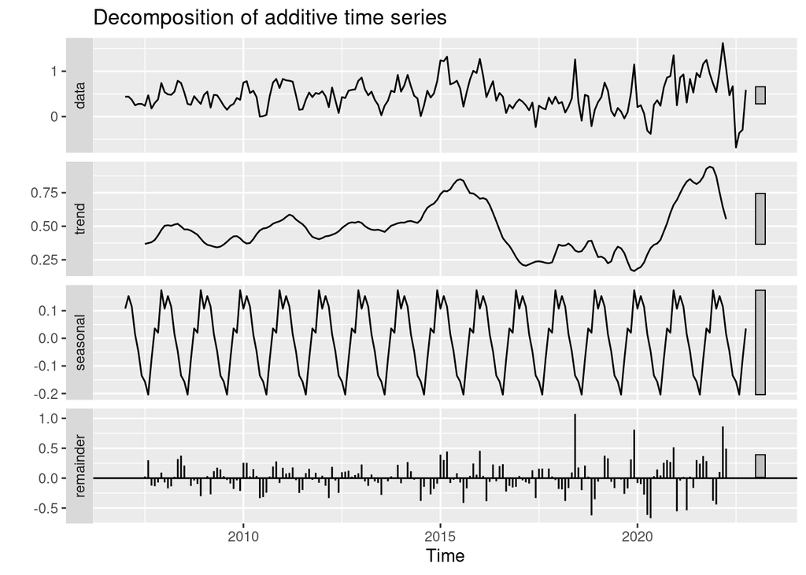

Para verificar a sazonalidade pode-se usar a função ggmonthplot

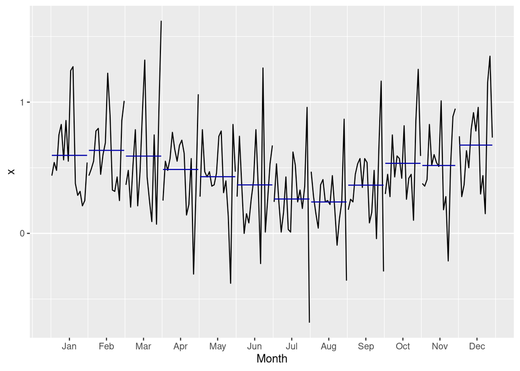